# Project 2

## Scientific question

What is the molecular basis of naturally developed human CCR5 mutation in HIV resistance?

## C-C motif chemokine receptor type 5 (CCR5)

CCR5 is a member of the beta chemokine receptor family composed of 7 transmembrane region (similar structure to G-protein coupled receptors). It is expressed predominantely by T cells, macrophages, and dendritic cells and can bind and transduce CCL3, CCL4, and CCL5 signaling.

CCR5 also serves as an important coreceptor for human immunodeficiency virus (HIV) entry into target cells. The heterotrimeric complex formed by gp120 (expressed by HIV) binding to CD4 and CCR5 (expressed on target cells) facilitates fusion of viral capsid with target cell membrane. Previous research has shown that a mutation of 32-base-pair deletion (delta-32) in the coding region of CCR5 gene which introduced a premature stop codon resulted in reduced CCR5 expression and induced HIV resistance in people carrying this mutation (Samson et al., 1996b). Mutations in other regions of CCR5 gene have been discovered, and some of which were capable of affecting CCR5 expression and structure integrity and therefore bear the potential of inducing HIV resistance in individuals carrying the mutation (Carrington et al., 1997b)(Blanpain et al., 1999b).

https://www.nature.com/articles/382722a0

https://www.cell.com/ajhg/fulltext/S0002-9297(07)60226-2

https://www.jbc.org/article/S0021-9258(19)74099-X/fulltext

## Hypothesis

If a mutation occurs on CCR5 that can influence the conformational integrity or structure of this molecule, which results in impaired CCR5 expression at cell surface or binding to gp120 expressed by HIV, then the cell carrying this mutation will be resistant to HIV infection.

### Data

Structure of heterotrimeric complex of CD4-gp120-CCR5 is found in protein data bank (https://www.rcsb.org/) using PDB ID: 6MET (Shaik et al., 2018)https://www.nature.com/articles/s41586-018-0804-9.

Structure of wild-type CCR5 was derived from the structure of CD4-gp120-CCR5 complex (6MET) using PyMol software.

Sequences of wild-type CCR5, CCR5-delta-32, and other beta chemokine receptors were found in NCBI (https://www.ncbi.nlm.nih.gov/gene/1234).

Sequence of CCR5 with C20S and C101A mutation was derived from wild-type CCR5 protein sequence based on information of location and amino acid involved in the mutation found in scientific papers mentioned above.

### Database

NCBI: National Center for Biotechnology Information (NCBI) is part of the United States National Library of Medicine. It "houses a series of batabases relevant to biotechnology and biomedicine and is an important resource for bioinformatics tools and services".

PDB: Protein Data Bank (PDB)"is a database for the three-dimensional structural data of large biological molecules, such as proteins and nucleic acids".

### Methods

Structural bioinformatics was used to obtain the 3D structure of CD4-gp120-CCR5 complex to support the statement that CCR5 is an essential molecule involved facinilating HIV entrance into target cells. The structural data of CD4-gp120-CCR5 complex was obtained from PDB, and the the structure was also used to present 3D structure of wild-type CCR5 that was not bound to any inhibitors or ligands.

Homology modeling was used to obtain the 3D structures of mutated CCR5 (delta-32, C20S, and C101A), of which the structural data could not be found online with designated PDB ID. Homology modeling was performed using SWISS-MODEL (https://swissmodel.expasy.org/) with protein sequences of the mutated CCR5. This allowed visualization of overall structural difference between wild-type and mutant CCR5.

3D protein measurement was used to quantify difference in structures between the wild-type CCR5 and the mutated versions. Protein sequences were directly extracted from PDB files obtained in homology modeling.

Sequence logos was used to visualize the level of conservation at each amino acid position to determine if the mutations examined occured at conserved region of beta chemokine receptor family. The aligned protein sequences used for sequence logos were obtained from multiple sequence alignment.

## Packages

#### NumPy

NumPy stands for numeric python. It is a library containing multidimentional array objects and functions and methods that can be used to access or modify the array objects.

#### Pandas

Pandas is a data manipulation tool that provides data structures used to process labeled or related data. Using Pandas package, data can be stored as Series (1-dimentional data) or DataFrames (2-dimentional data).

#### Matplotlib

Matplotlib package is a library used for visualizing data. Matplotlib.pyplot is a module in Matplotlib package which is designed to plot figures in the same way as MATLAB. Matplotlib.image is another module in Matplotlib package which allows image display.

#### Bio

BioPython package is commonly used for bioinformatics analysis. It is a collection of modules that can be used for sequence analysis, read data from genetic databases, and run bioinformatic analytical tools. AlignIO is a module in BioPython which can be used to read or write sequence alignment data files in multiple formats. SeqIO is a module in BioPython which can be used to read and write files containing sequence information in multiple formats. Bio.PDB is a module in BioPython that is used to process and visualize 3D structures of biological macromolecules. Bio.SeqUtils.ProtParam is a module in BioPython used for protein analysis based on its sequence. It can calculate basic properties of the protein based on the amino acid sequence.

#### nglview

NglView package is an IPython widget that is used to visualize 3D structures of molecules in an interactive manner.

#### logomaker

LogoMaker package is used to illustarte properties of DNA, RNA, and protein sequences using data from a matrix of amino acid or nucleotid frequency of a sequence or a multiple sequence alignment.

```python
# import all necessary packages
import numpy as np
import pandas as pd
import matplotlib.pyplot as plt
import matplotlib.image as mpimg
from Bio import AlignIO
from Bio import SeqIO
from Bio import PDB
from Bio.PDB import *
from Bio.SeqUtils.ProtParam import ProteinAnalysis
import nglview as nv
import logomaker as lg
```

## Structural bioinformatics and homology modeling

Structural bioinformatics is the analysis and prediction of 3D structure of biological macromolecules.

Homologi modeling is the prediction of the 3D structure of a protein based on its amino acid sequence and experimentally produced 3D structures of homologous proteins.

In both cases, PDB files are read and displayed.

PDB files store textual information describing the 3D structures of biological macromolecules.

```python
# read structure data in pdb file and show structure as a NGLWidget and assign it to global variable view
view=nv.show_structure_file("6met_CD4_gp120_CCR5.pdb")
# present only the protein of the structure as cartoon, and color each chain of the complex with different color
view.add_cartoon("protein",color_scheme="chainindex")
# visualize the complex structure
view
# unable to color by chainindex
```

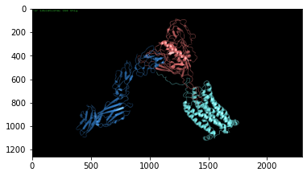

```python
# alternative solution
# read in a png image demonstrating the CD4-gp120-CCR5 complex created using PyMol data stored in a numpy array
# CD4 is colored blue, gp120 is red, and CCR5 is cyan
# data read in from the png image is assigned to global variable complex_image
complex_image = mpimg.imread("CD4_gp120_CCR5.png")
# uncomment code to check type of complex_image
# print(type(complex_image))
# visualize data of the png image and assign the visualized image to global variable_show
complex_show = plt.imshow(complex_image)
# show image
plt.show()
```

```python
# Homology modeling performed by SWISS-MODEL to obtain protein structures of CCR5 mutant alleles. (https://swissmodel.expasy.org/)
# data download as pdb files
# define function show_pdb_file to create a more convenient way of visualizing all structures
# parameter file is the name of pdb file that need to be visualized
# parameter struc_format is the format of how the molecule will be presented, default presentation as cartoon
# parameter structure_sele is the part of the molecule to be presented, default presentation as protein
# parameter structure_color is the color the molecule will be presented in, default set to blue
# all parameters are local variables
def show_pdb_file(file, struc_format="cartoon", structure_sele="protein", structure_color="blue"):
    # visualize the struture in file and assign the visualized structure to local variable view
    view = nv.show_structure_file(file)
    # clear all presentation format of the structure
    view.clear()
    # present the structure in assigned format, selected portion, and color
    view.add_representation(struc_format, selection=structure_sele,color=structure_color)
    # show structure
    return view
```

```python
# show structure of wild-type CCR5 protein using previously defined function
show_pdb_file("CCR5.pdb")
```

```python
# show structure of CCR5 protein with delta-32 mutation in red using previously defined function
show_pdb_file("delta_32.pdb", structure_color="red")
```

```python
# show structure of CCR5 protein with C20S mutation in green using previously defined function
show_pdb_file("C20S.pdb", structure_color="green")
```

```python
# show structure of CCR5 protein with C101A mutation in purple using previously defined function
show_pdb_file("C101A.pdb", structure_color="purple")
```

## Multiple sequence alignment

Multiple sequence alignment is a tool used to examine commonalities between different strands of genes or proteins by aligning three or more biological sequences. Alignment result can be used to deduce evolutionary relationship between sequences.

A fasta file containing protin sequences of all beta chemokine receptors to be aligned is read in. The sequences will be aligned in a way that they share the highest degree of similarity at each amino acid position. The alignment result will be stored to another fasta file in fasta formate.

```python
# I was unable to install mafft or clustalw algorithm in the terminal or through anachonda
# the following code for multiple sequence alignment cannot run successfully without installing the correct algorithm

# the locate of mafft algorithm in the terminal is assigned to a global variable mafft_exe
# mafft_exe = "/usr/local/bin/"
# name of the fasta file containing protein sequences of CCR is assignment to a global variable in_file
# in_file = "CCR_seq.fasta"
# sequences in the fasta file are aligned using algorithm stored at location mafft_exe
# parameter input is a local variable
# mafft_cline = MafftCommandline(mafft_exe, input=in_file)
# uncomment delow for code check
# print(mafft_cline)
# write a fasta file to store alignment data
# stdout, stderr = mafft_cline()
# with open("CCR_alignment.fasta", "w") as handle:
    # handle.write(stdout)
# parse data from the fasta file and assign to global variable alignments
# alignments = AlignIO.read("aligned.fasta", "fasta")
# print(alignments)
```

```python
# alignment data file obtained through mafft online server (https://mafft.cbrc.jp/alignment/server/).
# parse alignment data to global variable alignments
alignments = AlignIO.read(open("CCR_alignment.fasta"), "fasta")
# uncomment below for code check
# print(alignments)
```

## 3D protein measurement

3D protein measurement demonstrates features of proteins by quantfying the features through calculations performed based on the protein sequence. Comparing the result of 3D protein measurement allows a direct distinguish of structural difference between the proteins.

```python
# source code: https://towardsdatascience.com/visualizing-and-analyzing-proteins-in-python-bd99521ccd
# define a function protein_measurement to perform 3D protein measurement of proteins in pdb files
# parameter protein is the name of the protein to be analyzed
# parameter pdb_file is file to be read in and analyzed
# both parameters are local variables
def protein_measurement(protein, pdb_file):
    # extract protein sequence from the pdb file
    for record in SeqIO.parse(pdb_file, "pdb-atom"):
        # assign sequence to local variable sequence
        sequence=record.seq
    # uncomment below for code check
    # print(sequence)

    # convert sequence to the correct type for analysis and assign to local variable analyzed_seq
    analyzed_seq = ProteinAnalysis(str(sequence))
    # uncomment below for code check
    # print(type(analyzed_seq))

    # create an emtpy dictionary to store protein analysis result and assign the dictionary to local variable seq_analysis
    seq_analysis = {}
    # perform analysis
    # assign the name of analyzed protein as value to key sequence name
    seq_analysis['Sequence name'] = protein
    # assign the sequence of analyzed protein as value to key sequence
    seq_analysis['Sequence'] = str(sequence)
    # assign the length of sequence of analyzed protein as value to key sequence length
    seq_analysis['Sequence length'] = len(sequence)
    # assign the molecular weight of analyzed protein as value to key molecular weight
    seq_analysis['Molecular weight'] = analyzed_seq.molecular_weight()
    # assign the hydrophobicity level of analyzed protei as value to key GRAVY
    seq_analysis['GRAVY'] = analyzed_seq.gravy()
    # assign the secondary structure of analyzed protein (a tuple of helix, turn, and sheet) as value to key secondary structure
    seq_analysis['Secondary structure'] = analyzed_seq.secondary_structure_fraction()
    # uncomment below for code check
    # print(seq_info)

    # convert the dictionary into a pandas dataframe and assign dataframe to local variable seq_df
    seq_df=pd.DataFrame.from_dict(seq_analysis, orient='index')
    return seq_df
```

```python
# analyze wild-type CCR5 protein using defined function and assign result to global variable CCR5_analysis
CCR5_analysis=protein_measurement("CCR5", "CCR5.pdb")
# print result of analysis
print(CCR5_analysis)
```

```
                                                                     0
Sequence name                                                     CCR5
Sequence             MDYQVSSPIYDINYYTSEPCQKINVKQIAARLLPPLYSLVFIFGFV...
Sequence length                                                    313
Molecular weight                                             36152.628
GRAVY                                                         0.671565
Secondary structure  (0.47284345047923315, 0.17891373801916932, 0.2...
```

```python
# analyze CCR5 protein with delta-32 mutation using defined function and assign result to global variable delta_32_analysis
delta_32_analysis=protein_measurement("delta_32", "delta_32.pdb")
# print result of analysis
print(delta_32_analysis)
```

```
                                                                     0
Sequence name                                                 delta_32
Sequence             MDYQVSSPIYDINYYTSEPCQKINVKQIAARLLPPLYSLVFIFGFV...
Sequence length                                                    184
Molecular weight                                            20912.5359
GRAVY                                                         0.791848
Secondary structure  (0.47826086956521735, 0.18478260869565216, 0.2...
```

```python
# analyze CCR5 with C20S mutation using defined function and assign result to global variable C20S_analysis
C20S_analysis=protein_measurement("C20S", "C20S.pdb")
# print result of analysis
print(C20S_analysis)
```

```
                                                                     0
Sequence name                                                     C20S
Sequence             TSEPSQKINVKQIAARLLPPLYSLVFIFGFVGNMLVILILINCKRL...
Sequence length                                                    301
Molecular weight                                            34662.0202
GRAVY                                                          0.70299
Secondary structure  (0.4717607973421927, 0.1760797342192691, 0.239...
```

```python
# analyze CCR5 with C101A mutation using defined function and assign result to global variable C101A_analysis
C101A_analysis=protein_measurement("C101A", "C101A.pdb")
# print result of analysis
print(C101A_analysis)
```

```
                                                                     0
Sequence name                                                    C101A
Sequence             TSEPCQKINVKQIAARLLPPLYSLVFIFGFVGNMLVILILINCKRL...
Sequence length                                                    301
Molecular weight                                            34646.0208
GRAVY                                                         0.711628
Secondary structure  (0.4717607973421927, 0.17275747508305647, 0.24...
```

## Sequence logos

Sequence logos graphically demonstrates conserved regions between different strands of proteins or nucleotides.

```python
# create an empty list and assign the list to global variable seq_list
seq_list = list()
# append all alignment sequences from the alignment data to seq_list
for aln in alignments:
    sequence=str(aln.seq)
    seq_list.append(sequence)
# uncomment below for code check
# print(seq_list)
```

```python
# source code: https://logomaker.readthedocs.io/en/latest/examples.html
# create a matrix containing frequency of each amino acid at each position using the list created previously
# assign the matrix to global variable aln
aln=lg.alignment_to_matrix(sequences=seq_list, to_type='counts', characters_to_ignore='.-X')
# uncomment below for code check
# print(aln)
```

```
<logomaker.src.Logo.Logo at 0x1b1974a14f0>
```

[figure not shown]

```python
# plot sequence logos graph using the matrix created previously
lg.Logo(aln)
```